# Credit Card Users Churn Prediction

### Bivariate Analysis Summary on Numerical columns

- Age has no significant impact on target
- Dependent count on attrited customers IQR range between 2 and 3. Existing ranges from 1 to 6
- Total rel count is higher for attrited customers, less for existing customers
- Attrited customers are less inactive in the last 12 months period.
- Even the total revolving balance for attrited customers is less compared to the existing customers.
- Existing customers have more total transaction amounts and counts comparatively.
- Ratio of total transaction count from q1 to q4 is lower for attrited customers.
- Attrited customers spending the credits is way lesser than the existing customers spending.

### Bivariate analysis on categorical columns

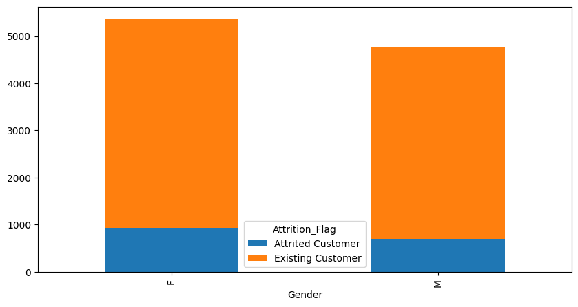

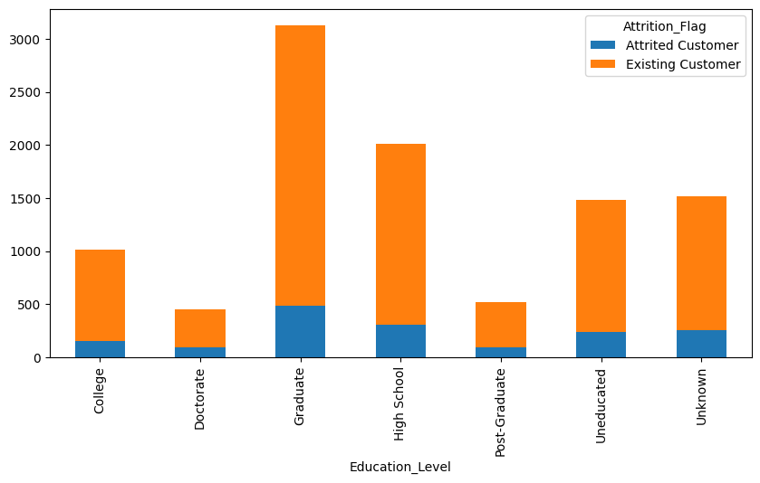

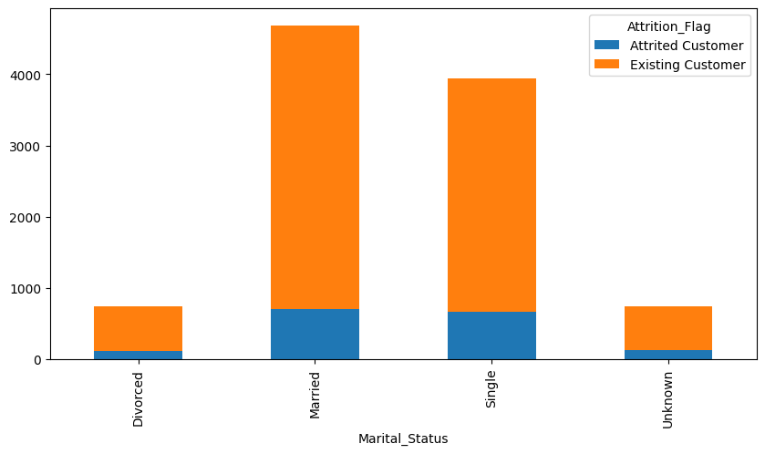

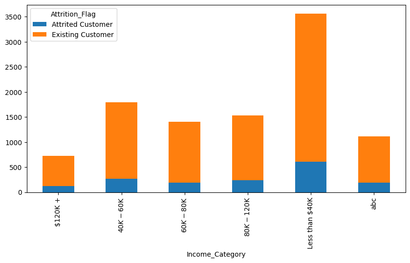

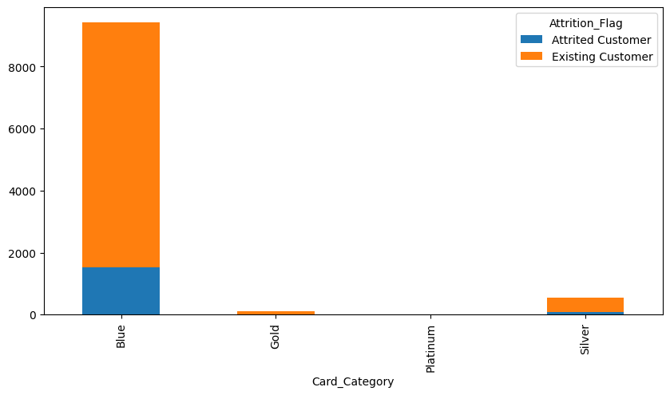

```python
for col in categorical_columns:
    pd.crosstab(df[col], df['Attrition_Flag']).plot(kind='bar', stacked=True, figsize=(10,5))
    plt.show()
```

### Question 1: How is the total transaction amount distributed?

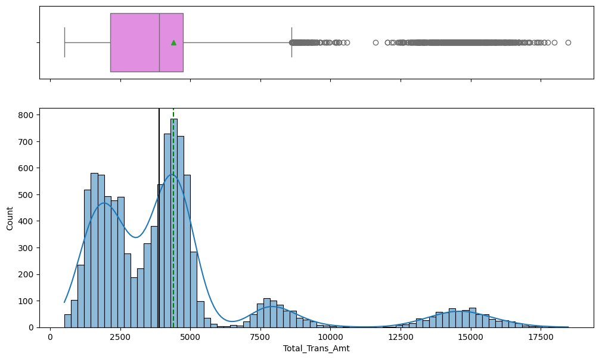

```python
histogram_boxplot(df, 'Total_Trans_Amt', kde=True)
```

- The mean triangle at the box plot is near 4500 which is above median line and indicates right skew.
- It has lots of outliers above 8500

### Question 2: What is the distribution of the level of education of customers?

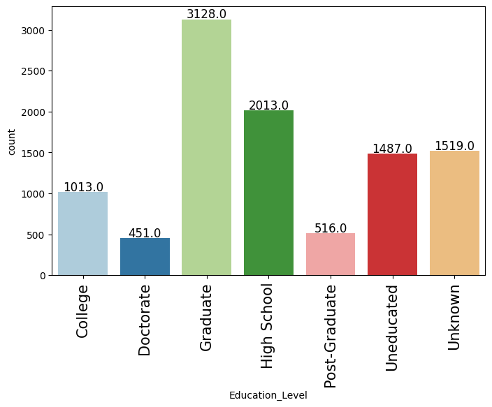

```python
labeled_barplot(df, 'Education_Level', 'Attrition_Flag')
```

### Question 3: What is the distribution of the level of income of customers?

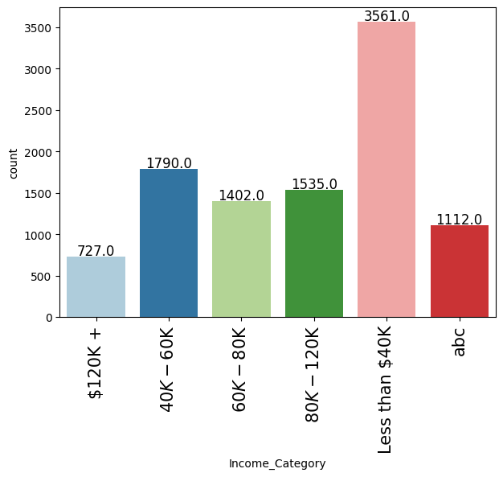

```python
labeled_barplot(df, 'Income_Category')
```